# 440 Reproducibility Capstone Project

First we need to set the working Directory.

Then we need to load the data.

```r
dat<-read.csv("Results.csv")
```

Let’s take a look at the data.

```r
str(dat)
```

```
## 'data.frame':    122 obs. of  5 variables:
##  $ Sex      : Factor w/ 3 levels "","Female","Male": 2 2 2 3 2 3 2 3 2 2 ...
##  $ Age      : Factor w/ 8 levels "","18 to 24",..: 2 2 4 2 3 2 2 3 2 2 ...
##  $ Education: Factor w/ 6 levels "","Associate degree",..: 6 6 2 6 6 6 6 6 6 6 ...
##  $ Condition: Factor w/ 2 levels "Conformity","Control": 2 1 2 2 2 1 1 2 2 1 ...
##  $ Response : int  11 14 14 7 7 14 14 7 11 11 ...
```

Response should be a Factor not an Integer, so let’s fix that real quick.

```r
dat$Response<-factor(dat$Response)
```

And check our work.

```r
str(dat)
```

```
## 'data.frame':    122 obs. of  5 variables:
##  $ Sex      : Factor w/ 3 levels "","Female","Male": 2 2 2 3 2 3 2 3 2 2 ...
##  $ Age      : Factor w/ 8 levels "","18 to 24",..: 2 2 4 2 3 2 2 3 2 2 ...
##  $ Education: Factor w/ 6 levels "","Associate degree",..: 6 6 2 6 6 6 6 6 6 6 ...
##  $ Condition: Factor w/ 2 levels "Conformity","Control": 2 1 2 2 2 1 1 2 2 1 ...
##  $ Response : Factor w/ 4 levels "7","11","12",..: 2 4 4 1 1 4 4 1 2 2 ...
```

Okay that worked, yes! There are some Responses that have a NA. So since we want to exclude that data, we will get rid of the NAs to avoid confusion.

```r
dat<-dat[!is.na(dat$Response),]
```

Great, now we will use the data to see if Response is independent of Condition. To do this I first need to run a Chi-Square of independence to test to the hypothesis that Response and Condition are independent.

```r
chisq.test(dat$Condition,dat$Response)
```

```
##
##  Pearson's Chi-squared test
##
## data:  dat$Condition and dat$Response
## X-squared = 9.6903, df = 3, p-value = 0.02139
```

Pearson’s Chi-squared test

data: dat$Condition and dat$Response X-squared = 9.6903, df = 3, p-value = 0.02139

Now let’s create a graph

```r
library(dplyr)
```

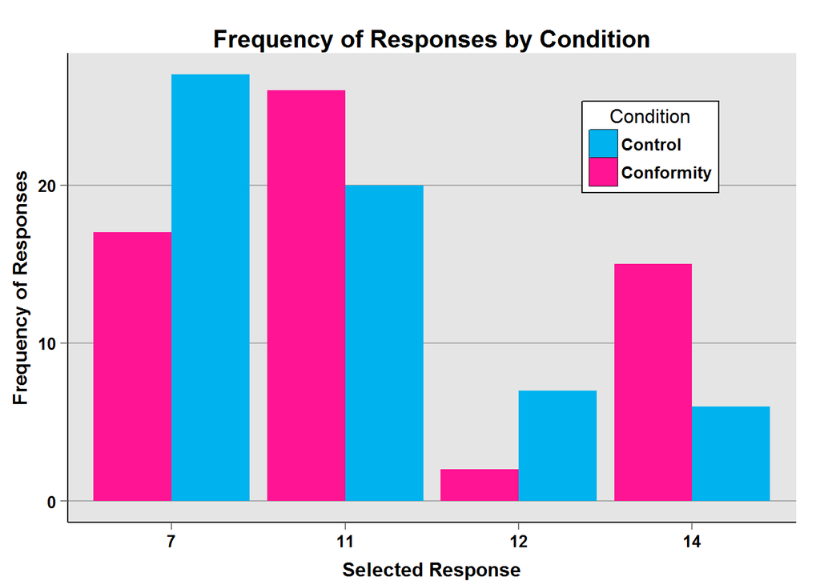

```r
library(ggplot2)
temp<-dat%>%group_by(Condition,Response)%>%
    summarize(frequency=length(Response))
library("gplots")
col1=col2hex("deeppink")
col2=col2hex("deepskyblue2")
f<-ggplot(temp, aes(x=Response, y=frequency, fill=Condition))+
    geom_bar(stat="identity",position=position_dodge())+
    scale_fill_manual(values=c(col1,col2),name="Condition",breaks=c("Control","Conformity"),labels=c("Control", "Conformity"))+
    theme(legend.key=element_rect(color="black"))+
    ggtitle("Frequency of Responses by Condition")+
    labs(x="Selected Response",y="Frequency of Responses")+
    theme(plot.title=element_text(size=15,face="bold",vjust=.5))+
    theme(axis.title.x=element_text(size=12,face="bold",vjust=-.25))+
    theme(axis.title.y=element_text(size=12,face="bold",vjust=1))+
    theme(axis.text.x=element_text(size=10,face="bold",color="black"))+
    theme(axis.text.y=element_text(size=10,face="bold",color="black"))+
    theme(panel.border=element_blank(),axis.line=element_line())+
    theme(panel.grid.major.x=element_blank())+
    theme(panel.grid.major.y=element_line(color="darkgrey"))+
    theme(panel.grid.minor.y=element_blank())+
    theme(legend.position=c(.8,.80))+
    theme(legend.background=element_blank())+
    theme(legend.background=element_rect(color="black"))+
    theme(legend.title=element_blank())+
    theme(legend.title=element_text(size=12))+
    theme(legend.title.align=.5)+
    theme(legend.text=element_text(size=10,face="bold"))
f
```